# R-Tipps

# readClipboard

setwd(readClipboard())

> [#Rstats](https://twitter.com/hashtag/Rstats?src=hash&ref_src=twsrc%5Etfw): When using setwd(), R expects forward-slashes in the directory name. But on Windows, copying the directory from folder gives back-slashes. To ‘de-windowsify’ the path name, copy the windows directory  
> & use:  
> setwd(readClipboard())[#phdchat](https://twitter.com/hashtag/phdchat?src=hash&ref_src=twsrc%5Etfw) [#phd](https://twitter.com/hashtag/phd?src=hash&ref_src=twsrc%5Etfw) [pic.twitter.com/cMbdmhNVuf](https://t.co/cMbdmhNVuf)

> — Guy Prochilo 🏳️ 🌈 (@GuyProchilo) [January 9, 2019](https://twitter.com/GuyProchilo/status/1083117541210370048?ref_src=twsrc%5Etfw)

# separate

> One form of messy data is a table in which multiple variables are stored in a single column. The [#tidyverse](https://twitter.com/hashtag/tidyverse?src=hash&ref_src=twsrc%5Etfw) separate() function will transform this type of data into one column per variable by simply specifying the separator! [#rstats](https://twitter.com/hashtag/rstats?src=hash&ref_src=twsrc%5Etfw) [#tidytuesday](https://twitter.com/hashtag/tidytuesday?src=hash&ref_src=twsrc%5Etfw) [#animation](https://twitter.com/hashtag/animation?src=hash&ref_src=twsrc%5Etfw) [#dataviz](https://twitter.com/hashtag/dataviz?src=hash&ref_src=twsrc%5Etfw) [pic.twitter.com/jjVvqWToIg](https://t.co/jjVvqWToIg)

> — Omni Analytics Group (@OmniAnalytics) [January 22, 2019](https://twitter.com/OmniAnalytics/status/1087740310699032576?ref_src=twsrc%5Etfw)

# glue

> 🤩 glue:: finally clicked for me this AM! 🤓  
> I work with monthly data files and need to update filenames often. My go-to is paste0(). Gave glue() another try. Way less fiddling with commas & quote marks, and it's easier to see the filename. [#Rstats](https://twitter.com/hashtag/Rstats?src=hash&ref_src=twsrc%5Etfw) [#tidyverse](https://twitter.com/hashtag/tidyverse?src=hash&ref_src=twsrc%5Etfw) [pic.twitter.com/EdpozMxrtM](https://t.co/EdpozMxrtM)

> — Adam Stone (@foundinblank) [January 23, 2019](https://twitter.com/foundinblank/status/1088025539191939073?ref_src=twsrc%5Etfw)

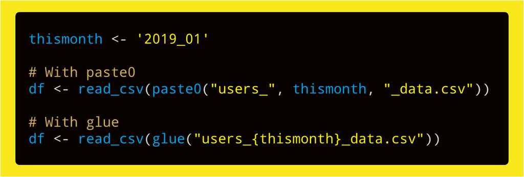

> [#RStats](https://twitter.com/hashtag/RStats?src=hash&ref_src=twsrc%5Etfw) — {dplyr} debugging tip: put a browser() somewhere inside your mutate() call to have access to the intermediate elements and to the columns: [pic.twitter.com/KN53YJIMOe](https://t.co/KN53YJIMOe)

> — Colin Fay 🤘 (@_ColinFay) [January 23, 2019](https://twitter.com/_ColinFay/status/1088022736117645314?ref_src=twsrc%5Etfw)